# Tarea Programada 2

José Eduardo Vindas Artavia

2026-06-18

# Carga, exploración y calidad de datos

## Carga de paquetes y tablas

```r
# Carga de bibliotecas requeridas
library(nycflights13)
library(dplyr)
library(ggplot2)
library(tidyr)
library(lubridate)
library(DT)

# Carga de las cinco tablas del paquete
data("flights")
data("airlines")
data("airports")
data("planes")
data("weather")
```

## Vista paginada de las primeras 100 observaciones de flights

```r
datatable(
  head(flights, 100),
  options = list(pageLength = 10, scrollX = TRUE),
  caption = "Primeras 100 observaciones de flights"
)
```

|  | year | month | day | dep_time | sched_dep_time | dep_delay | arr_time | sched_arr_time | arr_delay | carrier | flight | tailnum | origin | dest | air_time | distance | hour | minute | time_hour |
| --- | --- | --- | --- | --- | --- | --- | --- | --- | --- | --- | --- | --- | --- | --- | --- | --- | --- | --- | --- |
| 1 | 2013 | 1 | 1 | 517 | 515 | 2 | 830 | 819 | 11 | UA | 1545 | N14228 | EWR | IAH | 227 | 1400 | 5 | 15 | 2013-01-01T10:00:00Z |
| 2 | 2013 | 1 | 1 | 533 | 529 | 4 | 850 | 830 | 20 | UA | 1714 | N24211 | LGA | IAH | 227 | 1416 | 5 | 29 | 2013-01-01T10:00:00Z |
| 3 | 2013 | 1 | 1 | 542 | 540 | 2 | 923 | 850 | 33 | AA | 1141 | N619AA | JFK | MIA | 160 | 1089 | 5 | 40 | 2013-01-01T10:00:00Z |
| 4 | 2013 | 1 | 1 | 544 | 545 | -1 | 1004 | 1022 | -18 | B6 | 725 | N804JB | JFK | BQN | 183 | 1576 | 5 | 45 | 2013-01-01T10:00:00Z |
| 5 | 2013 | 1 | 1 | 554 | 600 | -6 | 812 | 837 | -25 | DL | 461 | N668DN | LGA | ATL | 116 | 762 | 6 | 0 | 2013-01-01T11:00:00Z |
| 6 | 2013 | 1 | 1 | 554 | 558 | -4 | 740 | 728 | 12 | UA | 1696 | N39463 | EWR | ORD | 150 | 719 | 5 | 58 | 2013-01-01T10:00:00Z |
| 7 | 2013 | 1 | 1 | 555 | 600 | -5 | 913 | 854 | 19 | B6 | 507 | N516JB | EWR | FLL | 158 | 1065 | 6 | 0 | 2013-01-01T11:00:00Z |
| 8 | 2013 | 1 | 1 | 557 | 600 | -3 | 709 | 723 | -14 | EV | 5708 | N829AS | LGA | IAD | 53 | 229 | 6 | 0 | 2013-01-01T11:00:00Z |
| 9 | 2013 | 1 | 1 | 557 | 600 | -3 | 838 | 846 | -8 | B6 | 79 | N593JB | JFK | MCO | 140 | 944 | 6 | 0 | 2013-01-01T11:00:00Z |
| 10 | 2013 | 1 | 1 | 558 | 600 | -2 | 753 | 745 | 8 | AA | 301 | N3ALAA | LGA | ORD | 138 | 733 | 6 | 0 | 2013-01-01T11:00:00Z |

[output cut: 90 more lines]

## Tabla resumen de dimensiones y tipos de variables

```r
resumen_tablas <- data.frame(
  Tabla = c("flights", "airlines", "airports", "planes", "weather"),
  Filas = c(nrow(flights), nrow(airlines), nrow(airports), nrow(planes), nrow(weather)),
  Columnas = c(ncol(flights), ncol(airlines), ncol(airports), ncol(planes), ncol(weather)),
  Tipo_de_Variables = c("Numérico, carácter",
                     "Carácter",
                     "Carácter, numérico",
                     "Carácter, numérico",
                     "Numérico, carácter")
                      )

datatable(resumen_tablas, caption = "Resumen de dimensiones y tipos de variables por tabla")
```

|  | Tabla | Filas | Columnas | Tipo_de_Variables |
| --- | --- | --- | --- | --- |
| 1 | flights | 336776 | 19 | Numérico, carácter |
| 2 | airlines | 16 | 2 | Carácter |
| 3 | airports | 1458 | 8 | Carácter, numérico |
| 4 | planes | 3322 | 9 | Carácter, numérico |
| 5 | weather | 26115 | 15 | Numérico, carácter |

## Valores faltantes en variables principales de flights

```r
total_filas <- nrow(flights)

valores_faltantes <- data.frame(
  Variable = c("dep_time", "dep_delay", "arr_time", "arr_delay", "tailnum"),
  Faltantes = c(
    sum(is.na(flights$dep_time)),
    sum(is.na(flights$dep_delay)),
    sum(is.na(flights$arr_time)),
    sum(is.na(flights$arr_delay)),
    sum(is.na(flights$tailnum))
  )
) %>%
   mutate(Porcentaje = round(Faltantes / total_filas * 100, 2))

datatable(
  valores_faltantes,
  options = list(dom = "t"),
  caption = "Valores faltantes en variables principales de flights"
)
```

|  | Variable | Faltantes | Porcentaje |
| --- | --- | --- | --- |
| 1 | dep_time | 8255 | 2.45 |
| 2 | dep_delay | 8255 | 2.45 |
| 3 | arr_time | 8713 | 2.59 |
| 4 | arr_delay | 9430 | 2.8 |
| 5 | tailnum | 2512 | 0.75 |

Los valores faltantes en dep_time, dep_delay, arr_time y arr_delay corresponden a vuelos cancelados. Los faltantes en tailnum indican que no se registró la aeronave del vuelo.

## Creación de variables derivadas

```r
flights <- flights %>%
  mutate(
    Fecha = ymd(paste(year, month, day, sep = "-")),
    Cancelado = is.na(dep_time),
    Retraso_Llegada = ifelse(Cancelado, NA, arr_delay > 15)
  )

datatable(
  head(select(flights, Fecha, dep_time, arr_delay, Cancelado, Retraso_Llegada), 10),
  options = list(dom = "t"),
  caption = "Variables Derivadas"
)
```

|  | Fecha | dep_time | arr_delay | Cancelado | Retraso_Llegada |
| --- | --- | --- | --- | --- | --- |
| 1 | 2013-01-01 | 517 | 11 | False | False |
| 2 | 2013-01-01 | 533 | 20 | False | True |
| 3 | 2013-01-01 | 542 | 33 | False | True |
| 4 | 2013-01-01 | 544 | -18 | False | False |
| 5 | 2013-01-01 | 554 | -25 | False | False |
| 6 | 2013-01-01 | 554 | 12 | False | False |
| 7 | 2013-01-01 | 555 | 19 | False | True |
| 8 | 2013-01-01 | 557 | -14 | False | False |
| 9 | 2013-01-01 | 557 | -8 | False | False |
| 10 | 2013-01-01 | 558 | 8 | False | False |

# Integración y preparación de datos

## Construcción de vuelos_analisis

```r
# Cantidad original de vuelos
filas_original <- nrow(flights)

# Se realiza unión con airlines para incorporar información de la aerolínea
vuelos_analisis <- flights %>%
  left_join(airlines %>% rename(nombre_aerolinea = name), by = "carrier")
nrow(vuelos_analisis)
```

```
## [1] 336776
```

```r
# Se realiza unión con airports para incorporar información del aeropuerto de destino
vuelos_analisis <- vuelos_analisis %>%
  left_join(airports %>% select(faa, name) %>% rename(nombre_destino = name),
            by = c("dest" = "faa"))
nrow(vuelos_analisis)
```

```
## [1] 336776
```

```r
# Se realiza unión con planes para agregar características de la aeronave
vuelos_analisis <- vuelos_analisis %>%
  left_join(planes %>% select(tailnum, year, manufacturer, model, seats) %>%
              rename(year_fabricacion = year), by = "tailnum")
nrow(vuelos_analisis)
```

```
## [1] 336776
```

```r
# Se realiza unión con weather para agregar las condiciones meteorológicas
vuelos_analisis <- vuelos_analisis %>%
  left_join(weather %>% select(origin, time_hour, temp, visib, wind_speed, precip),
            by = c("origin", "time_hour"))

nrow(vuelos_analisis)
```

```
## [1] 336776
```

Se utiliza left_join() para conservar la totalidad de los registros de la tabla flights como referencia principal. Cuando un vuelo no encuentra correspondencia en la tabla complementaria, el registro se mantiene en la base de datos y los campos sin coincidencia se representan con NA, lo que garantiza que ningún vuelo se pierda durante el proceso de integración.

## Comprobación del número de vuelos luego de las uniones

```r
filas_original == nrow(vuelos_analisis)
```

```
## [1] TRUE
```

Lo anterior evidencia que las uniones no generaron duplicados ni aumentaron indebidamente el número de vuelos.

## Registros sin correspondencia

```r
# Cantidad de vuelos sin información de aerolínea
sum(is.na(vuelos_analisis$nombre_aerolinea))
```

```
## [1] 0
```

```r
# Cantidad de vuelos sin información de aeropuerto
sum(is.na(vuelos_analisis$nombre_destino))
```

```
## [1] 7602
```

```r
# Cantidad de vuelos sin información de la aeronave
sum(is.na(vuelos_analisis$manufacturer))
```

```
## [1] 52606
```

```r
# Cantidad de vuelos sin información meteorológica
sum(is.na(vuelos_analisis$temp))
```

```
## [1] 1573
```

**Posibles causas de los faltantes:**  
Aerolínea: Sin valores faltantes, todos los vuelos tienen correspondencia con la tabla airlines.

Aeropuerto: 7602 vuelos sin información, Esto puede deberse a que algunos aeropuertos no figuran en la tabla airports, ya sea por tratarse de aeropuertos internacionales, regionales o con identificadores distintos a los del catálogo utilizado.

Aeronave: 52606 vuelos sin datos del fabricante, las causas más probables son matrículas no registradas en la tabla planes, aeronaves arrendadas que no figuran en el catálogo, o aviones de reciente incorporación sin historial documentado.

Meteorología: 1573 vuelos sin datos climáticos, Puede explicarse por fallas en estaciones meteorológicas, ausencia de cobertura para ciertos aeropuertos, o simplemente porque no se registraron condiciones para algunas horas o fechas específicas.

## Construcción de una base depurada

```r
# Se eliminan únicamente los registros que no poseen información esencial para analizar retrasos de vuelos, usando solo los vuelos completados.
vuelos_limpios <- vuelos_analisis %>%
  filter(!is.na(dep_delay), !is.na(arr_delay))

# Cantidad de registros después de la depuración
nrow(vuelos_limpios)
```

```
## [1] 327346
```

Se mantienen los valores faltantes de variables secundarias porque podrían ser de utilidad en otros análisis. Pero se eliminan observaciones que carecen de variables fundamentales para estudiar los retrasos de los vuelos, es decir los vuelos completados.

# Visualización de datos

## Número mensual de vuelos por aeropuerto de origen

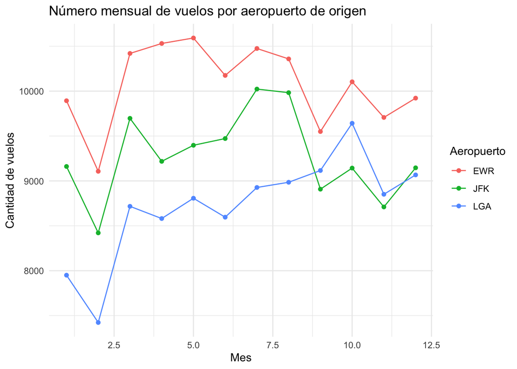

```r
# Número de vuelos por mes y aeropuerto de origen.
vuelos_mes <- flights %>%
  group_by(month, origin) %>%
  summarise(total = n())

# Gráfico
ggplot(vuelos_mes, aes(x = month, y = total, color = origin)) +
  geom_line() +
  geom_point() +
  labs( title = "Número mensual de vuelos por aeropuerto de origen",
        x = "Mes",
        y = "Cantidad de vuelos",
        color = "Aeropuerto" ) +
  theme_minimal()
```

## 10 destinos que recibieron mayor cantidad de vuelos

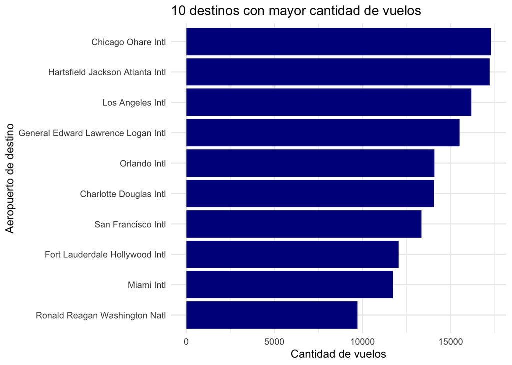

```r
# 10 destinos con mayor cantidad de vuelos.
destinos <- vuelos_analisis %>%
  group_by(nombre_destino) %>%
  summarise(total = n()) %>%
  arrange(desc(total)) %>%
  slice_head(n = 10)

# Gráfico
ggplot(destinos,
       aes(x = reorder(nombre_destino, total),
           y = total)) +
  geom_col(fill = "#00008B") +
  coord_flip() +
  labs(
    title = "10 destinos con mayor cantidad de vuelos",
    x = "Aeropuerto de destino",
    y = "Cantidad de vuelos"
  ) +
  theme_minimal()
```

## Comparación del retraso de llegada entre los aeropuertos de origen

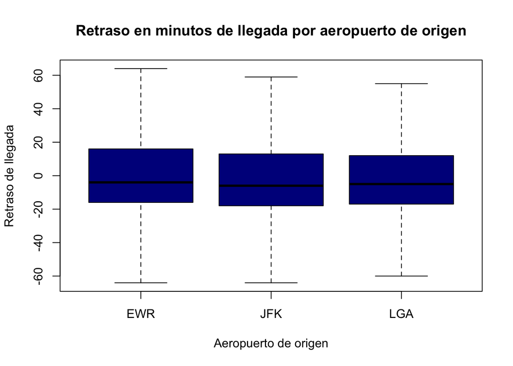

```r
boxplot(
  arr_delay ~ origin,
  data = vuelos_limpios,
  outline = FALSE,
  main = "Retraso en minutos de llegada por aeropuerto de origen",
  xlab = "Aeropuerto de origen",
  ylab = "Retraso de llegada",
  col = "#00008B"
)
```

## Relación entre una condición meteorológica y el retraso de salida

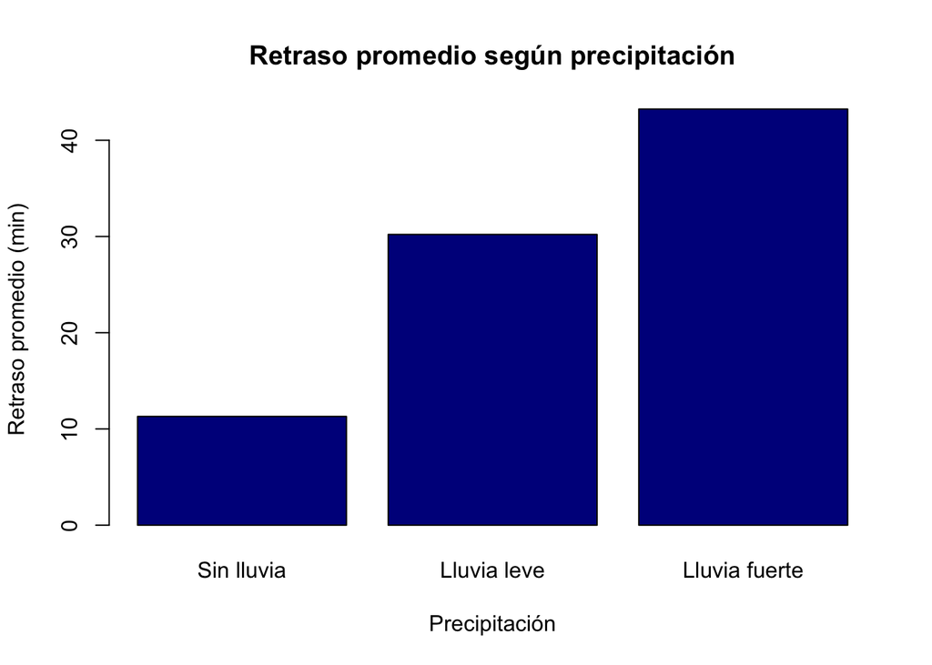

```r
preciptaciones_resumen <- vuelos_limpios %>%
  filter(!is.na(precip)) %>%
  mutate(
      categoria = cut(precip,
      breaks = c(-Inf, 0, 0.25, Inf),
      labels = c("Sin lluvia", "Lluvia leve", "Lluvia fuerte")
    )
  ) %>%
  group_by(categoria) %>%
  summarise(
    retraso_promedio = mean(dep_delay, na.rm = TRUE)
  )

barplot(
  preciptaciones_resumen$retraso_promedio,
  names.arg = preciptaciones_resumen$categoria,
  main = "Retraso promedio según precipitación",
  xlab = "Precipitación",
  ylab = "Retraso promedio (min)",
  col = "#00008B"
)
```

Se utilizó la precipitación como variable meteorológica debido a que las condiciones de lluvia o nieve pueden afectar las operaciones en los aeropuertos y contribuir a retrasos en la salida de los vuelos.

## Tasa de cancelación por mes

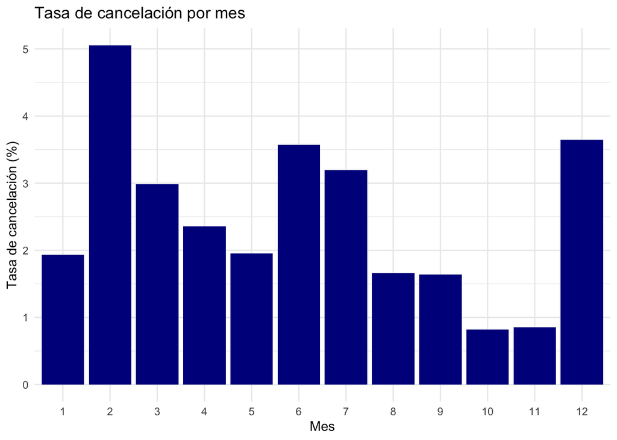

```r
# Tasa de cancelación por mes
cancelacion_mes <- flights %>%
  group_by(month) %>%
  summarise(
    tasa = mean(is.na(dep_time)) * 100
  )

# Gráfico
ggplot(cancelacion_mes, aes(x = factor(month), y = tasa)) +
  geom_col(fill = "#00008B") +
  labs(
    title = "Tasa de cancelación por mes",
    x = "Mes",
    y = "Tasa de cancelación (%)") +
  theme_minimal()
```

La tasa de cancelación varía a lo largo del año. El mes de febrero presenta la tasa más alta, con aproximadamente un 5% de los vuelos cancelados. Por otro lado, octubre y noviembre registran las tasas más bajas, inferiores al 1%.

# Estadística descriptiva

## Media, mediana, varianza y desviación estándar de arr_delay

```r
tabla_calculos <- vuelos_limpios %>%
  summarise(
    media = round(mean(arr_delay, na.rm = TRUE), 2),
    mediana = round(median(arr_delay, na.rm = TRUE), 2),
    varianza = round(var(arr_delay, na.rm = TRUE), 2),
    desviacion_estandar = round(sd(arr_delay, na.rm = TRUE), 2)
    )

colnames(tabla_calculos) <- c("Media", "Mediana", "Varianza", "Desviacion Estándar")

datatable(
  tabla_calculos,
  options = list(dom = "t"),
  caption = "Estadísticas descriptivas del retraso de llegada en vuelos completados"
)
```

|  | Media | Mediana | Varianza | Desviacion Estándar |
| --- | --- | --- | --- | --- |
| 1 | 6.9 | -5 | 1992.13 | 44.63 |

## Tabla resumen por aerolínea

```r
resumen_aerolinea <- vuelos_analisis %>%
  group_by(carrier, nombre_aerolinea) %>%
  summarise(
    vuelos = n(),
    porcentaje_cancelacion = (round(mean(as.numeric(Cancelado), na.rm = TRUE) * 100, 2)),
    media_retraso = round(mean(arr_delay, na.rm = TRUE), 2),
    mediana_retraso = round(median(arr_delay, na.rm = TRUE), 2)
  ) %>%
  arrange(desc(media_retraso))

colnames(resumen_aerolinea) <- c("Carrier", "Aerolínea", "Vuelos", "Porcentaje Cancelación", "Media Retraso", "Mediana Retraso")

datatable(
  resumen_aerolinea,
  caption = "Resumen por aerolínea",
  options = list(pageLength = 8, scrollX = TRUE)
)
```

|  | Carrier | Aerolínea | Vuelos | Porcentaje Cancelación | Media Retraso | Mediana Retraso |
| --- | --- | --- | --- | --- | --- | --- |
| 1 | F9 | Frontier Airlines Inc. | 685 | 0.44 | 21.92 | 6 |
| 2 | FL | AirTran Airways Corporation | 3260 | 2.24 | 20.12 | 5 |
| 3 | EV | ExpressJet Airlines Inc. | 54173 | 5.2 | 15.8 | -1 |
| 4 | YV | Mesa Airlines Inc. | 601 | 9.32 | 15.56 | -2 |
| 5 | OO | SkyWest Airlines Inc. | 32 | 9.38 | 11.93 | -7 |
| 6 | MQ | Envoy Air | 26397 | 4.67 | 10.77 | -1 |
| 7 | WN | Southwest Airlines Co. | 12275 | 1.56 | 9.65 | -3 |
| 8 | B6 | JetBlue Airways | 54635 | 0.85 | 9.46 | -3 |
| 9 | 9E | Endeavor Air Inc. | 18460 | 5.66 | 7.38 | -7 |
| 10 | UA | United Air Lines Inc. | 58665 | 1.17 | 3.56 | -6 |

[output cut: 6 more lines]

## Tabla de contingencia origin vs cancelado

```r
tabla_origen <- table(vuelos_analisis$origin,
    vuelos_analisis$Cancelado)

tabla_origen <- round(prop.table(tabla_origen, 1) * 100, 2)

colnames(tabla_origen) <- c("No cancelado (%)", "Cancelado (%)")

tabla_origen
```

```
##
##       No cancelado (%) Cancelado (%)
##   EWR            97.32          2.68
##   JFK            98.33          1.67
##   LGA            96.99          3.01
```

## Hallazgo usando clima o aeronaves

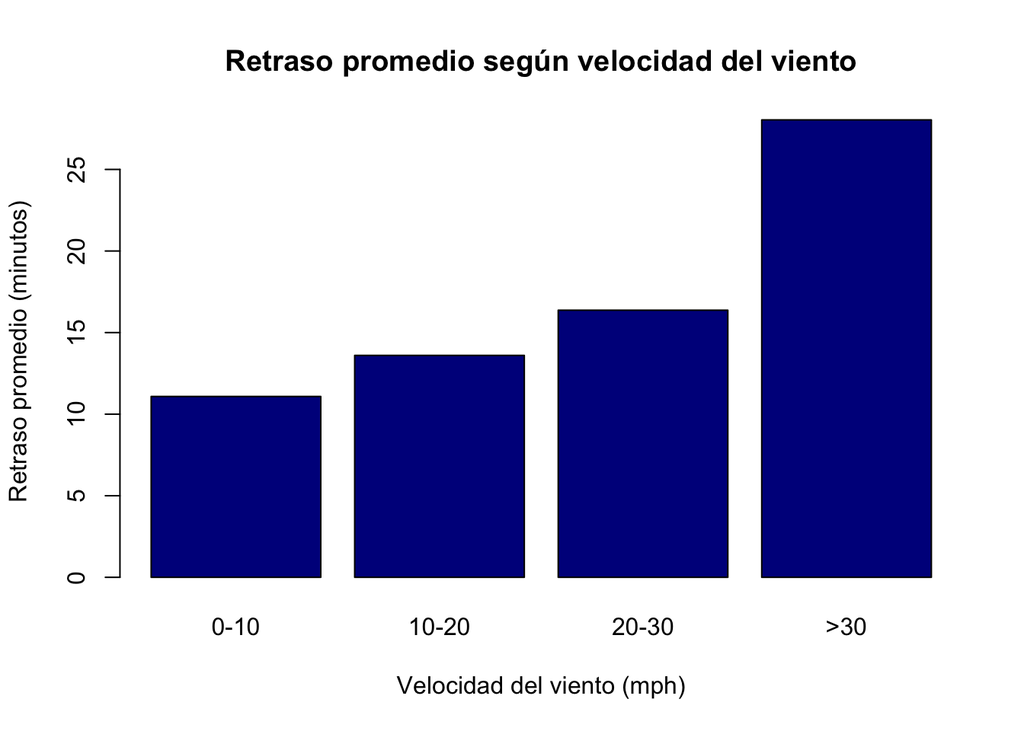

```r
retraso_viento <- vuelos_analisis %>%
  filter(!is.na(wind_speed), !is.na(dep_delay)) %>%
  mutate(
      viento = cut(
      wind_speed,
      breaks = c(0, 10, 20, 30, Inf),
      labels = c("0-10", "10-20", "20-30", ">30")
          )
    ) %>%
  filter(!is.na(viento)) %>%
  group_by(viento) %>%
  summarise(
    retraso_promedio = mean(dep_delay)
  )

barplot(
  retraso_viento$retraso_promedio,
  names.arg = retraso_viento$viento,
  main = "Retraso promedio según velocidad del viento",
  xlab = "Velocidad del viento (mph)",
  ylab = "Retraso promedio (minutos)",
  col = "#00008B"
)
```

Con este gráfico podemos ver que a mayor velocidad del viento, hay un mayor retraso promedio de salida, esto porque con condiciones climatológicas adversas se dificultan más los despejes.